# Exploring Kickstarter Project Data

## Preliminary Wrangling

This document explores a dataset comprised of various attributes for an assortment of 3786 Kickstarter projects

```python
# import all packages and set plots to be embedded inline
import numpy as np
import pandas as pd
import matplotlib.pyplot as plt
import seaborn as sb

%matplotlib inline
```

```python
# Import dataset
# Dataset downloaded from CSV link under "2019-05-16" on site: https://webrobots.io/kickstarter-datasets/
df = pd.read_csv('Kickstarter.csv')
```

```python
# Adding ability to view all dataframe columns
# as per https://stackoverflow.com/questions/49188960/how-to-show-all-of-columns-name-on-pandas-dataframe/49189503
pd.set_option('display.max_columns', None)
df.head()
```

|  | backers_count | blurb | category | converted_pledged_amount | country | created_at | creator | currency | currency_symbol | currency_trailing_code | current_currency | deadline | disable_communication | friends | fx_rate | goal | id | is_backing | is_starrable | is_starred | launched_at | location | name | permissions | photo | pledged | profile | slug | source_url | … |
| --- | --- | --- | --- | --- | --- | --- | --- | --- | --- | --- | --- | --- | --- | --- | --- | --- | --- | --- | --- | --- | --- | --- | --- | --- | --- | --- | --- | --- | --- | --- |
| 0 | 0 | An intelligent, heavy terrain construction robot. | {"id":338,"name":"Robots","slug":"technology/r... | 0 | SE | 1467285495 | {"id":2051859794,"name":"Nikola Andrasic","slu... | SEK | kr | True | USD | 1470343868 | False | NaN | 0.108102 | 39250000.0 | 1118204694 | NaN | False | NaN | 1467751868 | {"id":906057,"name":"Stockholm","slug":"stockh... | OMNI - Intelligent Construction Robots (Canceled) | NaN | {"key":"assets/012/911/440/fa9bf5eab584bcf892d... | 0.0 | {"id":2581325,"project_id":2581325,"state":"in... | omni-intelligent-construction-robots | https://www.kickstarter.com/discover/categorie... | … |
| 1 | 5 | Twelve months of gorgeous local Brisbane model... | {"id":325,"name":"Calendars","slug":"publishin... | 154 | AU | 1399379096 | {"id":429445942,"name":"Sarah and Ryan","slug"... | AUD | $ | True | USD | 1402392877 | False | NaN | 0.717612 | 1000.0 | 339216274 | NaN | False | NaN | 1399800877 | {"id":1100661,"name":"Brisbane","slug":"brisba... | Diamond's 2015 Cosplay Calendar | NaN | {"key":"assets/011/699/764/4c0071a29260f73cefa... | 165.0 | {"id":1009980,"project_id":1009980,"state":"in... | dr-rys-diamonds | https://www.kickstarter.com/discover/categorie... | … |
| 2 | 1 | This is a short film about married Marines who... | {"id":293,"name":"Drama","slug":"film & video/... | 1 | US | 1528203193 | {"id":1911329541,"name":"Gary Winstead","is_re... | USD | $ | True | USD | 1530903638 | False | NaN | 1.000000 | 5000.0 | 496127063 | NaN | False | NaN | 1528225238 | {"id":2363919,"name":"Big Bear Lake","slug":"b... | The Lady In RED | NaN | {"key":"assets/021/475/491/1f51ff654672a21e6ec... | 1.0 | {"id":3397649,"project_id":3397649,"state":"in... | the-lady-in-red | https://www.kickstarter.com/discover/categorie... | … |
| 3 | 111 | A photo book tracing the sites of Spain's 114,... | {"id":280,"name":"Photobooks","slug":"photogra... | 11812 | NL | 1510400357 | {"id":629822067,"name":"Miquel Gonzalez","slug... | EUR | € | False | USD | 1521457200 | False | NaN | 1.129418 | 9500.0 | 254714563 | NaN | False | NaN | 1518691174 | {"id":727232,"name":"Amsterdam","slug":"amster... | MEMORIA PERDIDA: Spain's Lost Memory 1936-1975 | NaN | {"key":"assets/019/174/183/64b643192d4295d0910... | 9626.0 | {"id":3216003,"project_id":3216003,"state":"ac... | memoria-perdida-recovering-spains-lost-memory-... | https://www.kickstarter.com/discover/categorie... | … |
| 4 | 53 | "The Root of Perfection" is a science-fiction ... | {"id":301,"name":"Science Fiction","slug":"fil... | 3663 | US | 1528341672 | {"id":2054701261,"name":"Cole Daniel Hills","i... | USD | $ | True | USD | 1532586600 | False | NaN | 1.000000 | 3500.0 | 2030913793 | NaN | False | NaN | 1530398677 | {"id":2400052,"name":"Erie","slug":"erie-pa","... | THE ROOT OF PERFECTION | NaN | {"key":"assets/021/749/712/6247ecebf162ce3520f... | 3663.5 | {"id":3399126,"project_id":3399126,"state":"in... | the-root-of-perfection | https://www.kickstarter.com/discover/categorie... | … |

```python
df.info()
```

```
<class 'pandas.core.frame.DataFrame'>
RangeIndex: 3786 entries, 0 to 3785
Data columns (total 37 columns):
backers_count               3786 non-null int64
blurb                       3786 non-null object
category                    3786 non-null object
converted_pledged_amount    3786 non-null int64
country                     3786 non-null object
created_at                  3786 non-null int64
creator                     3786 non-null object
currency                    3786 non-null object
currency_symbol             3786 non-null object
currency_trailing_code      3786 non-null bool
current_currency            3786 non-null object
deadline                    3786 non-null int64
disable_communication       3786 non-null bool
friends                     1 non-null object
fx_rate                     3786 non-null float64
goal                        3786 non-null float64
id                          3786 non-null int64
is_backing                  1 non-null object
is_starrable                3786 non-null bool
is_starred                  1 non-null object
launched_at                 3786 non-null int64
location                    3784 non-null object
name                        3786 non-null object
permissions                 1 non-null object
photo                       3786 non-null object
pledged                     3786 non-null float64
profile                     3786 non-null object
slug                        3786 non-null object
source_url                  3786 non-null object
spotlight                   3786 non-null bool
staff_pick                  3786 non-null bool
state                       3786 non-null object
state_changed_at            3786 non-null int64
static_usd_rate             3786 non-null float64
urls                        3786 non-null object
usd_pledged                 3786 non-null float64
usd_type                    3775 non-null object
dtypes: bool(5), float64(5), int64(7), object(20)
memory usage: 965.1+ KB
```

```python
df.duplicated().value_counts()
```

```
False    3786
dtype: int64
```

```python
# Make copy of main dataframe so as to keep original data intact.
df_copy = df.copy()
df_copy.shape
```

```
(3786, 37)
```

## Tracking Data Quality and Tidiness Issues:

### Quality:

- Variables "friends", "is_backing", "is_starred", and "permissions" only have one entry and should be dropped
- Per https://help.kickstarter.com/hc/en-us/articles/115005135834-What-is-Spotlight-:
  - Variable 'spotlight' should be dropped, since it only applies to successful projects after the fact, and is thus not a predictor of anything.
- Variables "created_at", "deadline", "launched_at", and "state_changed_at" are set in unix time instead of readable datetime
- Variables with financial values such as "converted_pledged_amount", "goal", "pledged", and "usd_pledged" are set to different decimal places, and should be rounded to at most two decimal places
- Only two entries are missing data for "location" (not a big deal, given that we have "country" data; these)
- Only eleven entries are missing data for "usd_type" (this variable is not important to the investigation)

### Tidiness:

- Data entries in the columns "category", "creator", "location", "photo", "profile", and "urls" contain multiple pieces of information. If separated, they could be their own dataframes or made into additional columns in the main dataframe.
  - The "category" variable can garner category and sub-category info for the projects
  - The "location" variable can garner data regarding the project's state name, city name, and city type
  - The "creator","photo", "profile", "urls" variables have no data that is relevant to this project and should be dropped

## Addressing Data Quality and Tidiness Issues

### Quality:

#### Remove (essentially) empty columns and 'spotlight'

```python
df_copy = df_copy.drop(columns = ["friends", "is_backing", "is_starred", "permissions", "spotlight"])
df_copy.shape
```

```
(3786, 32)
```

#### Fix time categories

```python
# Converting unix time to readable date-time
# as per https://stackoverflow.com/questions/19231871/convert-unix-time-to-readable-date-in-pandas-dataframe
date_cols = ["created_at", "deadline", "launched_at", "state_changed_at"]
for i in date_cols:
    df_copy[i] = pd.to_datetime(df_copy[i],unit='s')

df_copy[date_cols].head()
```

|  | created_at | deadline | launched_at | state_changed_at |
| --- | --- | --- | --- | --- |
| 0 | 2016-06-30 11:18:15 | 2016-08-04 20:51:08 | 2016-07-05 20:51:08 | 2016-07-15 06:09:53 |
| 1 | 2014-05-06 12:24:56 | 2014-06-10 09:34:37 | 2014-05-11 09:34:37 | 2014-06-10 09:34:37 |
| 2 | 2018-06-05 12:53:13 | 2018-07-06 19:00:38 | 2018-06-05 19:00:38 | 2018-07-06 19:00:38 |
| 3 | 2017-11-11 11:39:17 | 2018-03-19 11:00:00 | 2018-02-15 10:39:34 | 2018-03-19 11:00:00 |
| 4 | 2018-06-07 03:21:12 | 2018-07-26 06:30:00 | 2018-06-30 22:44:37 | 2018-07-26 06:30:01 |

```python
df_copy[date_cols].describe()
```

|  | created_at | deadline | launched_at | state_changed_at |
| --- | --- | --- | --- | --- |
| count | 3786 | 3786 | 3786 | 3786 |
| unique | 3773 | 3760 | 3772 | 3764 |
| top | 2018-04-15 15:07:02 | 2015-01-01 04:59:00 | 2015-12-17 20:21:14 | 2018-04-07 22:59:00 |
| freq | 2 | 3 | 2 | 2 |
| first | 2009-11-11 15:18:08 | 2010-02-09 15:25:00 | 2009-11-12 00:58:51 | 2010-02-09 15:30:08 |
| last | 2019-04-13 03:23:17 | 2019-06-16 13:59:02 | 2019-04-17 15:24:20 | 2019-04-17 17:00:05 |

#### Fix financial categories

```python
# Round financial values to at most two decimal places
money_cols = ["converted_pledged_amount", "goal", "pledged", "usd_pledged"]
for i in money_cols:
    df_copy = df_copy.round(2)

df_copy[money_cols].head()
```

|  | converted_pledged_amount | goal | pledged | usd_pledged |
| --- | --- | --- | --- | --- |
| 0 | 0 | 39250000.0 | 0.0 | 0.00 |
| 1 | 154 | 1000.0 | 165.0 | 154.46 |
| 2 | 1 | 5000.0 | 1.0 | 1.00 |
| 3 | 11812 | 9500.0 | 9626.0 | 11914.72 |
| 4 | 3663 | 3500.0 | 3663.5 | 3663.50 |

### Tidiness:

#### Feature Engineering - address tidiness issue of "category" variable by creating variables holding extracted values for main category and sub-category:

```python
# View full string entries for "category" variable to gauge the complexity of category strings:
df_copy['category'][15]
```

```
'{"id":46,"name":"Children\'s Books","slug":"publishing/children\'s books","position":5,"parent_id":18,"color":14867664,"urls":{"web":{"discover":"http://www.kickstarter.com/discover/categories/publishing/children\'s%20books"}}}'
```

```python
df_copy['category'][798]
```

```
'{"id":39,"name":"Hip-Hop","slug":"music/hip-hop","position":8,"parent_id":14,"color":10878931,"urls":{"web":{"discover":"http://www.kickstarter.com/discover/categories/music/hip-hop"}}}'
```

```python
# Extract product categories and sub-catgories from strings in "category" variable into their own columns in dataframe
# (Used regular expression)

import re

df_copy['main_cat'] = ''
df_copy['sub_cat'] = ''

for i in np.arange(df_copy.shape[0]):
    match = re.findall('(([- &\'\\\\]|\w+)+)', df_copy['category'][i])
    df_copy['main_cat'][i] = match[5][0].title()
    df_copy['sub_cat'][i] = match[3][0].replace('\\','')
```

```python
df_copy[['name','main_cat', 'sub_cat', 'category']].head()
```

|  | name | main_cat | sub_cat | category |
| --- | --- | --- | --- | --- |
| 0 | OMNI - Intelligent Construction Robots (Canceled) | Technology | Robots | {"id":338,"name":"Robots","slug":"technology/r... |
| 1 | Diamond's 2015 Cosplay Calendar | Publishing | Calendars | {"id":325,"name":"Calendars","slug":"publishin... |
| 2 | The Lady In RED | Film & Video | Drama | {"id":293,"name":"Drama","slug":"film & video/... |
| 3 | MEMORIA PERDIDA: Spain's Lost Memory 1936-1975 | Photography | Photobooks | {"id":280,"name":"Photobooks","slug":"photogra... |
| 4 | THE ROOT OF PERFECTION | Film & Video | Science Fiction | {"id":301,"name":"Science Fiction","slug":"fil... |

```python
df_copy.main_cat.value_counts()
```

```
Music           589
Technology      553
Publishing      469
Theater         399
Film & Video    342
Food            287
Fashion         262
Crafts          206
Design          169
Games           160
Art             132
Comics           64
Photography      62
Journalism       55
Dance            37
Name: main_cat, dtype: int64
```

```python
df_copy.sub_cat.value_counts()
```

```
Fiction              210
Indie Rock           198
Accessories          198
Hip-Hop              166
Wearables            162
DIY                  141
Musical              138
Narrative Film       110
Radio & Podcasts      95
Metal                 77
Vegan                 72
Product Design        66
Experimental          66
Hardware              66
Plays                 62
Festivals             60
Software              59
Gaming Hardware       58
Spaces                56
Gadgets               51
Art Books             51
Farmer's Markets      49
Theater               44
Drinks                44
Comedy                44
Technology            43
Food Trucks           41
DIY Electronics       41
Apparel               38
Painting              38
                    ...
Pet Fashion            3
Space Exploration      3
People                 3
Audio                  3
Publishing             3
Textiles               3
Fashion                3
Kids                   2
Community Gardens      2
Photo                  2
Literary Spaces        2
Weaving                2
Stationery             2
Translations           2
Family                 2
Civic Design           1
Bacon                  1
Jewelry                1
Embroidery             1
Taxidermy              1
Childrenswear          1
Video                  1
Typography             1
Quilts                 1
Film & Video           1
Cookbooks              1
Residencies            1
Workshops              1
Fantasy                1
Games                  1
Name: sub_cat, Length: 138, dtype: int64
```

#### Feature Engineering - address tidiness issue of "location" variable by creating variables holding extracted values for state, city, and type of city:

```python
df_copy[df_copy.location.isnull()]
```

|  | backers_count | blurb | category | converted_pledged_amount | country | created_at | creator | currency | currency_symbol | currency_trailing_code | current_currency | deadline | disable_communication | fx_rate | goal | id | is_starrable | launched_at | location | name | photo | pledged | profile | slug | source_url | staff_pick | state | state_changed_at | static_usd_rate | … |
| --- | --- | --- | --- | --- | --- | --- | --- | --- | --- | --- | --- | --- | --- | --- | --- | --- | --- | --- | --- | --- | --- | --- | --- | --- | --- | --- | --- | --- | --- | --- |
| 1931 | 46 | “The Other Side of the Fence” is a compelling ... | {"id":31,"name":"Narrative Film","slug":"film ... | 10000 | US | 2010-01-12 22:27:24 | {"id":1016417245,"name":"Logical Chaos","is_re... | USD | $ | True | USD | 2010-04-18 21:27:00 | False | 1.0 | 10000.0 | 943169460 | False | 2010-01-20 17:05:18 | NaN | Endangered Wildlife: The Other Side of the Fence | {"key":"assets/011/259/373/c46a6b61df90787295d... | 10000.0 | {"id":2656,"project_id":2656,"state":"inactive... | endangered-wildlife-the-other-side-of-the-fence | https://www.kickstarter.com/discover/categorie... | False | successful | 2010-04-18 21:30:07 | 1.0 | … |
| 3470 | 0 | Sawmill Boys tackles geography & environment, ... | {"id":50,"name":"Poetry","slug":"publishing/po... | 0 | US | 2010-05-07 14:15:32 | {"id":1768769269,"name":"Neva Bryan","is_regis... | USD | $ | True | USD | 2010-06-28 16:00:00 | False | 1.0 | 3000.0 | 498132862 | False | 2010-05-07 14:34:19 | NaN | Sawmill Boys: Getting the word out about mount... | {"key":"assets/011/261/977/a001038ebfcf2521c29... | 0.0 | {"id":5918,"project_id":5918,"state":"inactive... | sawmill-boys-getting-the-word-out-about-mounta... | https://www.kickstarter.com/discover/categorie... | False | failed | 2010-06-28 16:00:14 | 1.0 | … |

```python
# View full string entry for "location" variable of third row entry to gauge the complexity of location strings:
df_copy['location'][2]
```

```
'{"id":2363919,"name":"Big Bear Lake","slug":"big-bear-lake-ca","short_name":"Big Bear Lake, CA","displayable_name":"Big Bear Lake, CA","localized_name":"Big Bear Lake","country":"US","state":"CA","type":"Town","is_root":false,"urls":{"web":{"discover":"https://www.kickstarter.com/discover/places/bi…
```

```python
# Extract product (country) states, cities, and city types from strings in "location" variable into their own columns in dataframe
# (Used regular expression)

df_copy['location_state'] = ''
df_copy['location_city'] = ''
df_copy['location_type'] = ''

for i in np.arange(df_copy.shape[0]):
    if pd.notna(df_copy.location[i]) == True:
        match = re.findall('((?:[^"]\w+)+)', df_copy['location'][i])
        df_copy['location_state'][i] = match[17]
        df_copy['location_city'][i] = match[3]
        df_copy['location_type'][i] = match[19]
    else:
        df_copy['location_state'][i] = 'NaN'
        df_copy['location_city'][i] = 'NaN'
        df_copy['location_type'][i] = 'NaN'
```

```python
df_copy[['name', 'country', 'location_state', 'location_city', 'location_type', 'location']][1930:1933]
```

|  | name | country | location_state | location_city | location_type | location |
| --- | --- | --- | --- | --- | --- | --- |
| 1930 | Nomadplaneten - episk science fiction på svenska | SE | Vastra Gotaland | Gothenburg | Town | {"id":890869,"name":"Gothenburg","slug":"gothe... |
| 1931 | Endangered Wildlife: The Other Side of the Fence | US | NaN | NaN | NaN | NaN |
| 1932 | Tinderella Original Cast Recording | US | CA | San Francisco | Town | {"id":2487956,"name":"San Francisco","slug":"s... |

### What is the structure of your dataset?

There are 3786 Kickstarter projects in this dataset, with a total of 37 features, some of which are untidy, and some of which are not of interest for my exploration. I have engineered a few categorical features (related to project ctegories and location) which may come to be useful for exploration.

### What is/are the main feature(s) of interest in your dataset?

I am interested in finding out which project qualities correlate with different types of project outcomes (or, the final "state" of the project).

### What features in the dataset do you think will help support your investigation into your feature(s) of interest?

I believe the following features could illuminate patterns in project outcomes:

- Number of backers
- Length of time project was open
- Total money pledged (relative to funding goal)
- Project category
- Project location (country, city type)
- If project was "staff pick"

```python
# Save wrangled dataframe to new CSV file to make future manipulating easier
df_copy.to_csv('data_wrangled.csv', index=False)
```

## Streamlining Wrangled Dataset

### Removing extra variables, and engineering other potentially relevant features

```python
# import all packages and set plots to be embedded inline
import numpy as np
import pandas as pd
import matplotlib.pyplot as plt
import seaborn as sb

%matplotlib inline
```

```python
# Import wrangled dataset
df = pd.read_csv('data_wrangled.csv')
pd.set_option('display.max_columns', None)
df.head()
```

|  | backers_count | blurb | category | converted_pledged_amount | country | created_at | creator | currency | currency_symbol | currency_trailing_code | current_currency | deadline | disable_communication | fx_rate | goal | id | is_starrable | launched_at | location | name | photo | pledged | profile | slug | source_url | staff_pick | state | state_changed_at | static_usd_rate | … |
| --- | --- | --- | --- | --- | --- | --- | --- | --- | --- | --- | --- | --- | --- | --- | --- | --- | --- | --- | --- | --- | --- | --- | --- | --- | --- | --- | --- | --- | --- | --- |
| 0 | 0 | An intelligent, heavy terrain construction robot. | {"id":338,"name":"Robots","slug":"technology/r... | 0 | SE | 2016-06-30 11:18:15 | {"id":2051859794,"name":"Nikola Andrasic","slu... | SEK | kr | True | USD | 2016-08-04 20:51:08 | False | 0.11 | 39250000.0 | 1118204694 | False | 2016-07-05 20:51:08 | {"id":906057,"name":"Stockholm","slug":"stockh... | OMNI - Intelligent Construction Robots (Canceled) | {"key":"assets/012/911/440/fa9bf5eab584bcf892d... | 0.0 | {"id":2581325,"project_id":2581325,"state":"in... | omni-intelligent-construction-robots | https://www.kickstarter.com/discover/categorie... | False | canceled | 2016-07-15 06:09:53 | 0.12 | … |
| 1 | 5 | Twelve months of gorgeous local Brisbane model... | {"id":325,"name":"Calendars","slug":"publishin... | 154 | AU | 2014-05-06 12:24:56 | {"id":429445942,"name":"Sarah and Ryan","slug"... | AUD | $ | True | USD | 2014-06-10 09:34:37 | False | 0.72 | 1000.0 | 339216274 | False | 2014-05-11 09:34:37 | {"id":1100661,"name":"Brisbane","slug":"brisba... | Diamond's 2015 Cosplay Calendar | {"key":"assets/011/699/764/4c0071a29260f73cefa... | 165.0 | {"id":1009980,"project_id":1009980,"state":"in... | dr-rys-diamonds | https://www.kickstarter.com/discover/categorie... | False | failed | 2014-06-10 09:34:37 | 0.94 | … |
| 2 | 1 | This is a short film about married Marines who... | {"id":293,"name":"Drama","slug":"film & video/... | 1 | US | 2018-06-05 12:53:13 | {"id":1911329541,"name":"Gary Winstead","is_re... | USD | $ | True | USD | 2018-07-06 19:00:38 | False | 1.00 | 5000.0 | 496127063 | False | 2018-06-05 19:00:38 | {"id":2363919,"name":"Big Bear Lake","slug":"b... | The Lady In RED | {"key":"assets/021/475/491/1f51ff654672a21e6ec... | 1.0 | {"id":3397649,"project_id":3397649,"state":"in... | the-lady-in-red | https://www.kickstarter.com/discover/categorie... | False | failed | 2018-07-06 19:00:38 | 1.00 | … |
| 3 | 111 | A photo book tracing the sites of Spain's 114,... | {"id":280,"name":"Photobooks","slug":"photogra... | 11812 | NL | 2017-11-11 11:39:17 | {"id":629822067,"name":"Miquel Gonzalez","slug... | EUR | € | False | USD | 2018-03-19 11:00:00 | False | 1.13 | 9500.0 | 254714563 | False | 2018-02-15 10:39:34 | {"id":727232,"name":"Amsterdam","slug":"amster... | MEMORIA PERDIDA: Spain's Lost Memory 1936-1975 | {"key":"assets/019/174/183/64b643192d4295d0910... | 9626.0 | {"id":3216003,"project_id":3216003,"state":"ac... | memoria-perdida-recovering-spains-lost-memory-... | https://www.kickstarter.com/discover/categorie... | False | successful | 2018-03-19 11:00:00 | 1.24 | … |
| 4 | 53 | "The Root of Perfection" is a science-fiction ... | {"id":301,"name":"Science Fiction","slug":"fil... | 3663 | US | 2018-06-07 03:21:12 | {"id":2054701261,"name":"Cole Daniel Hills","i... | USD | $ | True | USD | 2018-07-26 06:30:00 | False | 1.00 | 3500.0 | 2030913793 | False | 2018-06-30 22:44:37 | {"id":2400052,"name":"Erie","slug":"erie-pa","... | THE ROOT OF PERFECTION | {"key":"assets/021/749/712/6247ecebf162ce3520f... | 3663.5 | {"id":3399126,"project_id":3399126,"state":"in... | the-root-of-perfection | https://www.kickstarter.com/discover/categorie... | False | successful | 2018-07-26 06:30:01 | 1.00 | … |

```python
# Remove unnecessary variables
df.drop(columns = ['category',
                   'converted_pledged_amount',
                   'creator',
                   'currency_symbol',
                   'currency_trailing_code',
                   'current_currency',
                   'disable_communication',
                   'fx_rate',
                   'location',
                   'photo',
                   'profile',
                   'slug',
                   'source_url',
                   'static_usd_rate',
                   'urls',
                   'usd_type'],
       inplace = True)
df.head()
```

|  | backers_count | blurb | country | created_at | currency | deadline | goal | id | is_starrable | launched_at | name | pledged | staff_pick | state | state_changed_at | usd_pledged | main_cat | sub_cat | location_state | location_city | location_type |
| --- | --- | --- | --- | --- | --- | --- | --- | --- | --- | --- | --- | --- | --- | --- | --- | --- | --- | --- | --- | --- | --- |
| 0 | 0 | An intelligent, heavy terrain construction robot. | SE | 2016-06-30 11:18:15 | SEK | 2016-08-04 20:51:08 | 39250000.0 | 1118204694 | False | 2016-07-05 20:51:08 | OMNI - Intelligent Construction Robots (Canceled) | 0.0 | False | canceled | 2016-07-15 06:09:53 | 0.00 | Technology | Robots | Stockholm | Stockholm | Town |
| 1 | 5 | Twelve months of gorgeous local Brisbane model... | AU | 2014-05-06 12:24:56 | AUD | 2014-06-10 09:34:37 | 1000.0 | 339216274 | False | 2014-05-11 09:34:37 | Diamond's 2015 Cosplay Calendar | 165.0 | False | failed | 2014-06-10 09:34:37 | 154.46 | Publishing | Calendars | QLD | Brisbane | Town |
| 2 | 1 | This is a short film about married Marines who... | US | 2018-06-05 12:53:13 | USD | 2018-07-06 19:00:38 | 5000.0 | 496127063 | False | 2018-06-05 19:00:38 | The Lady In RED | 1.0 | False | failed | 2018-07-06 19:00:38 | 1.00 | Film & Video | Drama | CA | Big Bear Lake | Town |
| 3 | 111 | A photo book tracing the sites of Spain's 114,... | NL | 2017-11-11 11:39:17 | EUR | 2018-03-19 11:00:00 | 9500.0 | 254714563 | False | 2018-02-15 10:39:34 | MEMORIA PERDIDA: Spain's Lost Memory 1936-1975 | 9626.0 | False | successful | 2018-03-19 11:00:00 | 11914.72 | Photography | Photobooks | North Holland | Amsterdam | Town |
| 4 | 53 | "The Root of Perfection" is a science-fiction ... | US | 2018-06-07 03:21:12 | USD | 2018-07-26 06:30:00 | 3500.0 | 2030913793 | False | 2018-06-30 22:44:37 | THE ROOT OF PERFECTION | 3663.5 | False | successful | 2018-07-26 06:30:01 | 3663.50 | Film & Video | Science Fiction | PA | Erie | Town |

#### Engineering features related to the time variables:

- created_at
- launched_at
- deadline
- state_changed_at

Reference:

http://www.datasciencemadesimple.com/difference-two-timestamps-seconds-minutes-hours-pandas-python-2/ https://docs.scipy.org/doc/numpy/reference/arrays.datetime.html

```python
# Confirm that time variables are of 'datetime64' type:
date_cols = ["created_at", "deadline", "launched_at", "state_changed_at"]
for i in date_cols:
    df[i] = pd.to_datetime(df[i])

df[date_cols].dtypes
```

```
created_at          datetime64[ns]
deadline            datetime64[ns]
launched_at         datetime64[ns]
state_changed_at    datetime64[ns]
dtype: object
```

```python
import datetime
from dateutil.relativedelta import relativedelta
from datetime import date
```

```python
# Calculate number of days it took to launch project: 'days_to_launch'
# (days between project creation and project launch: 'launched_at' - 'created_at')

df['days_to_launch'] = df['launched_at'] - df['created_at']
df['days_to_launch']=df['days_to_launch']/np.timedelta64(1,'D')
df.days_to_launch.head()
```

```
0     5.397836
1     4.881725
2     0.255150
3    95.958530
4    23.807928
Name: days_to_launch, dtype: float64
```

```python
# Calculate number of days given for project to succeed: 'days_to_succeed'
# (days between project launch and project deadline: 'deadline' - 'launched_at')

df['days_to_succeed'] = df['deadline'] - df['launched_at']
df['days_to_succeed']=df['days_to_succeed']/np.timedelta64(1,'D')
df.days_to_succeed.head()
```

```
0    30.000000
1    30.000000
2    31.000000
3    32.014190
4    25.323183
Name: days_to_succeed, dtype: float64
```

```python
# Calculate number of days project was active (or reached its final 'state') : 'days_active'
# (days between project launch and project deadline: 'state_changed_at' - 'launched_at')

df['days_active'] = df['state_changed_at'] - df['launched_at']
df['days_active']=df['days_active']/np.timedelta64(1,'D')
df.days_active.head()
```

```
0     9.388021
1    30.000000
2    31.000000
3    32.014190
4    25.323194
Name: days_active, dtype: float64
```

```python
# Confirm whether final 'state' occurred before or after 'deadline': 'ended_early'
# Faster code instead of for loops as per reference:
# https://stackoverflow.com/questions/27041724/using-conditional-to-generate-new-column-in-pandas-dataframe)

df['ended_early'] = np.where(df.days_active < df.days_to_succeed, True, False)
```

```python
df[['days_to_succeed','days_active','ended_early']].head()
```

|  | days_to_succeed | days_active | ended_early |
| --- | --- | --- | --- |
| 0 | 30.000000 | 9.388021 | True |
| 1 | 30.000000 | 30.000000 | False |
| 2 | 31.000000 | 31.000000 | False |
| 3 | 32.014190 | 32.014190 | False |
| 4 | 25.323183 | 25.323194 | False |

#### Engineering Feature: proportion of project funding relative to goal

```python
# Finding ratio of confirmed funds relative to funding goals: 'funded_prop'
# ('pledged' / 'goal')

df['funded_prop'] = df['pledged'] / df['goal']
df.funded_prop.head()
```

```
0    0.000000
1    0.165000
2    0.000200
3    1.013263
4    1.046714
Name: funded_prop, dtype: float64
```

#### Save cleaner dataframe to new CSV file to make future manipulating easier

```python
df.to_csv('data_cleaner.csv', index=False)
```

## Univariate Exploration

> In this section, investigate distributions of individual variables. If you see unusual points or outliers, take a deeper look to clean things up and prepare yourself to look at relationships between variables.

```python
# import all packages and set plots to be embedded inline
import numpy as np
import pandas as pd
import matplotlib.pyplot as plt
import seaborn as sb

%matplotlib inline
```

```python
# Import wrangled dataset
df = pd.read_csv('data_cleaner.csv')
pd.set_option('display.max_columns', None)
df.head()
```

|  | backers_count | blurb | country | created_at | currency | deadline | goal | id | is_starrable | launched_at | name | pledged | staff_pick | state | state_changed_at | usd_pledged | main_cat | sub_cat | location_state | location_city | location_type | days_to_launch | days_to_succeed | days_active | ended_early | funded_prop |
| --- | --- | --- | --- | --- | --- | --- | --- | --- | --- | --- | --- | --- | --- | --- | --- | --- | --- | --- | --- | --- | --- | --- | --- | --- | --- | --- |
| 0 | 0 | An intelligent, heavy terrain construction robot. | SE | 2016-06-30 11:18:15 | SEK | 2016-08-04 20:51:08 | 39250000.0 | 1118204694 | False | 2016-07-05 20:51:08 | OMNI - Intelligent Construction Robots (Canceled) | 0.0 | False | canceled | 2016-07-15 06:09:53 | 0.00 | Technology | Robots | Stockholm | Stockholm | Town | 5.397836 | 30.000000 | 9.388021 | True | 0.000000 |
| 1 | 5 | Twelve months of gorgeous local Brisbane model... | AU | 2014-05-06 12:24:56 | AUD | 2014-06-10 09:34:37 | 1000.0 | 339216274 | False | 2014-05-11 09:34:37 | Diamond's 2015 Cosplay Calendar | 165.0 | False | failed | 2014-06-10 09:34:37 | 154.46 | Publishing | Calendars | QLD | Brisbane | Town | 4.881725 | 30.000000 | 30.000000 | False | 0.165000 |
| 2 | 1 | This is a short film about married Marines who... | US | 2018-06-05 12:53:13 | USD | 2018-07-06 19:00:38 | 5000.0 | 496127063 | False | 2018-06-05 19:00:38 | The Lady In RED | 1.0 | False | failed | 2018-07-06 19:00:38 | 1.00 | Film & Video | Drama | CA | Big Bear Lake | Town | 0.255150 | 31.000000 | 31.000000 | False | 0.000200 |
| 3 | 111 | A photo book tracing the sites of Spain's 114,... | NL | 2017-11-11 11:39:17 | EUR | 2018-03-19 11:00:00 | 9500.0 | 254714563 | False | 2018-02-15 10:39:34 | MEMORIA PERDIDA: Spain's Lost Memory 1936-1975 | 9626.0 | False | successful | 2018-03-19 11:00:00 | 11914.72 | Photography | Photobooks | North Holland | Amsterdam | Town | 95.958530 | 32.014190 | 32.014190 | False | 1.013263 |
| 4 | 53 | "The Root of Perfection" is a science-fiction ... | US | 2018-06-07 03:21:12 | USD | 2018-07-26 06:30:00 | 3500.0 | 2030913793 | False | 2018-06-30 22:44:37 | THE ROOT OF PERFECTION | 3663.5 | False | successful | 2018-07-26 06:30:01 | 3663.50 | Film & Video | Science Fiction | PA | Erie | Town | 23.807928 | 25.323183 | 25.323194 | False | 1.046714 |

```python
# Set color for charts:
base_color = sb.color_palette()[0]
```

### What's the distribution of project campaign 'states'?

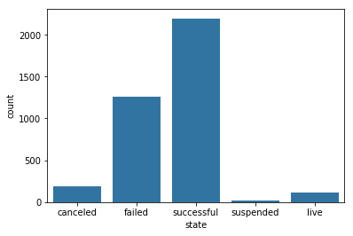

```python
sb.countplot(data = df, x = 'state', color = base_color);
```

Looks like more projects succeeded than not.

### What's the proportion of campaigns that ended early?

Plot 'ended_early' counts with proportion percentages over bars

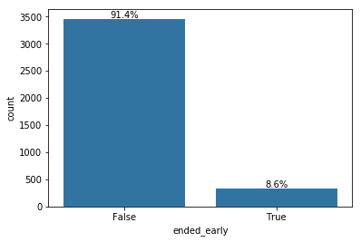

```python
# create the plot
ax = sb.countplot(data = df, x = 'ended_early', color = base_color)

# add annotations
# Reference: https://stackoverflow.com/questions/31749448/how-to-add-percentages-on-top-of-bars-in-seaborn
n_points = df.shape[0]
for p in ax.patches:
    height = p.get_height()
    ax.text(p.get_x()+p.get_width()/2.,
            height + 25,
            '{:0.1f}%'.format(100*height/n_points),
            ha = 'center')

plt.show()
```

#### Interjectionary Bivariate Exploration:

A follow-up bivariate exploration is called for to see whether the different campaign 'states' have a split within them regarding if they ended early.

```python
# Reference:
# https://stackoverflow.com/questions/33271098/python-get-a-frequency-count-based-on-two-columns-variables-in-pandas-datafra
df.groupby(['state','ended_early']).size()
```

```
state       ended_early
canceled    True            193
failed      False          1263
live        True            117
successful  False          2196
suspended   True             17
dtype: int64
```

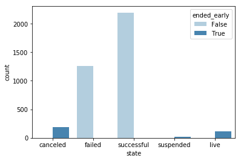

```python
sb.countplot(data = df, x = 'state', hue = 'ended_early', palette = 'Blues');
```

Since each project 'state' only has projects that EITHER ended early or didn't, there is no distribution of endings to be illustrated within each 'state'. We have learned and confirmed that, not surprisingly, all projects which were 'cancelled' or 'suspended' ended early, and all project campaigns that 'failed' or were 'successful' in reaching their funding goal were open until the end of their deadline.

Since I care about whether projects are successful or not, and 'live' project campaigns are still in progress and have yet to be cancelled or suspended, I will continue working with the dataset which excludes project rows that have the state of 'live'.

### What's the proportion of campaigns that ended early - given a removal of 'live' projects?

Plot 'ended_early' counts with proportion percentages over bars WHILE excluding 'live' projects - since they are still in progress and are skewing the chart.

```python
# Isolate sub-dataset which excludes projects that are 'live':
df_notlive = df[df['state']!='live']
df_notlive.shape
```

```
(3669, 26)
```

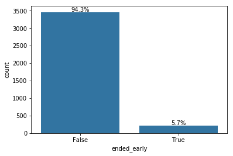

```python
# create the plot
ax = sb.countplot(data = df_notlive, x = 'ended_early', color = base_color)

# add annotations
n_points = df_notlive.shape[0]
for p in ax.patches:
    height = p.get_height()
    ax.text(p.get_x()+p.get_width()/2.,
            height + 25,
            '{:0.1f}%'.format(100*height/n_points),
            ha = 'center')

plt.show()
```

This represents the proportion of projects which actually ended early: those which we know to have been cancelled or suspended.

### Check distribution of 'is_starrable' relative to project 'state':

```python
df.groupby(['state','is_starrable']).size()
```

```
state       is_starrable
canceled    False            193
failed      False           1263
live        False              9
            True             108
successful  False           2196
suspended   False             17
dtype: int64
```

Since 'is_starrable' is only true for projects that are 'live', and I am excluding the 'live' projects, we can also remove the 'is_starrable' feature.

```python
df_notlive = df_notlive.drop(columns = 'is_starrable')
df_notlive.info()
```

```
<class 'pandas.core.frame.DataFrame'>
Int64Index: 3669 entries, 0 to 3785
Data columns (total 25 columns):
backers_count       3669 non-null int64
blurb               3669 non-null object
country             3669 non-null object
created_at          3669 non-null object
currency            3669 non-null object
deadline            3669 non-null object
goal                3669 non-null float64
id                  3669 non-null int64
launched_at         3669 non-null object
name                3669 non-null object
pledged             3669 non-null float64
staff_pick          3669 non-null bool
state               3669 non-null object
state_changed_at    3669 non-null object
usd_pledged         3669 non-null float64
main_cat            3669 non-null object
sub_cat             3669 non-null object
location_state      3667 non-null object
location_city       3667 non-null object
location_type       3667 non-null object
days_to_launch      3669 non-null float64
days_to_succeed     3669 non-null float64
days_active         3669 non-null float64
ended_early         3669 non-null bool
funded_prop         3669 non-null float64
dtypes: bool(2), float64(7), int64(2), object(14)
memory usage: 855.1+ KB
```

### What's the distribution of the number of backers per project?

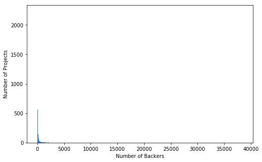

```python
binsize = 50
bins = np.arange(0, df_notlive['backers_count'].max()+binsize, binsize)

plt.figure(figsize=[8, 5])
plt.hist(data = df_notlive, x = 'backers_count', bins = bins)
plt.xlabel('Number of Backers')
plt.ylabel('Number of Projects')
plt.show();
```

Looks like there is a VERY wide distribution of backers, skewed by many projects having zero or few backers, and a few outlier projects with thousands of backers.

#### Let's zoom in a little:

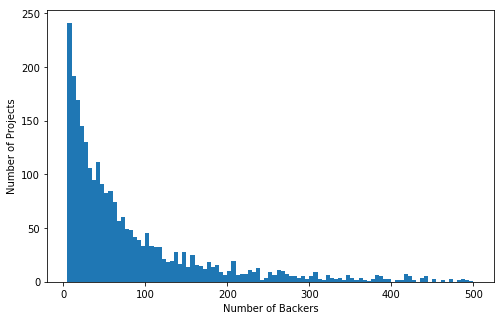

```python
binsize = 5
bins = np.arange(5, 500+binsize, binsize)

plt.figure(figsize=[8, 5])
plt.hist(data = df_notlive, x = 'backers_count', bins = bins)
plt.xlabel('Number of Backers')
plt.ylabel('Number of Projects')
plt.show();
```

#### Since there's a long tail in the distribution, let's put it on a log scale instead (thus exclusive of campaigns with no backers):

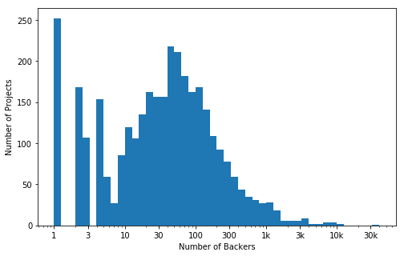

```python
log_binsize = 0.1
bins = 10 ** np.arange(0, np.log10(df_notlive['backers_count'].max())+log_binsize, log_binsize)

plt.figure(figsize=[8, 5])
plt.hist(data = df_notlive, x = 'backers_count', bins = bins)
plt.xscale('log')
plt.xticks([1, 3, 10, 30, 100, 300, 1e3, 3e3, 1e4, 3e4], [1, 3, 10, 30, 100, 300, '1k', '3k', '10k', '30k'])
plt.xlabel('Number of Backers')
plt.ylabel('Number of Projects')
plt.show();
```

There still appears to be an exponential tail, but at least it is a little more constrained under the log transformation. The log transformation illustrates a bimodal distribution - around 0 to 1 backers, and around 40 to 60 backers.

#### Let's see how many campaigns had fewer than 10 backers:

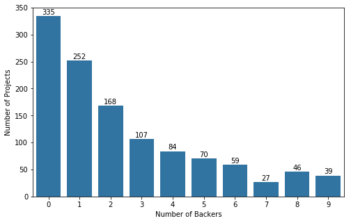

```python
# Plot countplot that illustrates how many projects have fewer than 10 backers:

plt.figure(figsize=[8, 5])
ax = sb.countplot(data = df_notlive, x = 'backers_count', color = base_color)
plt.xlabel('Number of Backers')
plt.ylabel('Number of Projects')
plt.xlim(-0.5,9.5)
plt.ylim(0,350)

# add annotations
for p in ax.patches[0:10]:
    height = p.get_height()
    ax.text(p.get_x()+p.get_width()/2.,
            height + 3,
            '{:.0f}'.format(height),
            ha = 'center')

plt.show()
```

Nearly 1/11 projects had 0 backers. Over one quarter of projects had 5 or fewer backers.

A follow-up bivariate exploration would be a comparison of the number of backers relative to successful and unsuccessful projects.

### What's the distribution of location type?

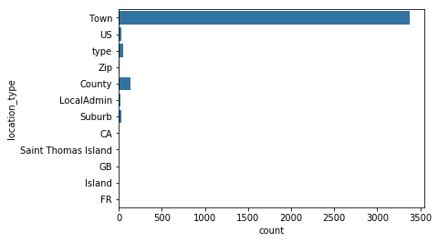

```python
sb.countplot(data = df_notlive, y = 'location_type', color = base_color);
```

Looks like I extracted that information incorrectly. However, even if I had, it's almost useless given the fairly little diversity in distribution of the location type, with the vast majority of projects being in towns. At least we've learned that much.

### What's the distribution of campaign countries?

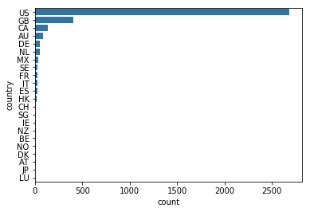

```python
sb.countplot(data = df_notlive, y = 'country', color = base_color, order = df_notlive.country.value_counts().index);
```

The vast majority of project campaigns are based in the US, followed by other English-speaking countries. There is some visible representation from Northern Europe, Mexico, Western Europe, and Hong Kong.

### What's the distribution of proportion of goal funded?

```python
df_notlive.funded_prop.describe()
```

```
count     3669.000000
mean         9.227679
std        455.514376
min          0.000000
25%          0.035000
50%          1.025400
75%          1.276000
max      27588.230000
Name: funded_prop, dtype: float64
```

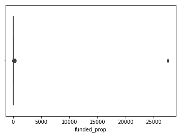

```python
sb.boxplot(data = df_notlive, x = 'funded_prop', color = base_color);
```

```python
over_funded = df_notlive[df_notlive.funded_prop >
                         df_notlive.funded_prop.quantile(.99)][['goal',
                                                                'pledged',
                                                                'funded_prop']].sort_values('funded_prop')
print(over_funded.shape)
print(over_funded)
```

```
(37, 3)
         goal     pledged   funded_prop
3088  24999.0   467833.01     18.714069
1676  15000.0   289456.00     19.297067
3412  19000.0   378775.00     19.935526
1913    300.0     6073.00     20.243333
1031     20.0      411.00     20.550000
3323    200.0     4127.00     20.635000
900    3500.0    72398.00     20.685143
3600     20.0      436.00     21.800000
3669    400.0     9201.00     23.002500
3103  50000.0  1186983.00     23.739660
3735      1.0       24.00     24.000000
2875   5000.0   123614.35     24.722870
1643    500.0    12427.00     24.854000
```

[output cut: 24 more lines]

Looks like some campaigns had quite the funding success: those past the 99th percentile had received more than 18.7 times their goal. In some cases the project's funding proportion was severely greater due to having a campaign goal as low as several hundred dollars - sometimes even ONLY $1.

#### Let's zoom in on the boxplot:

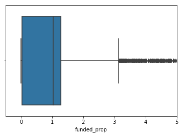

```python
sb.boxplot(data = df_notlive, x = 'funded_prop', color = base_color);
plt.xlim(-.5,5);
```

#### To see the distribution a bit better, we can employ a histogram:

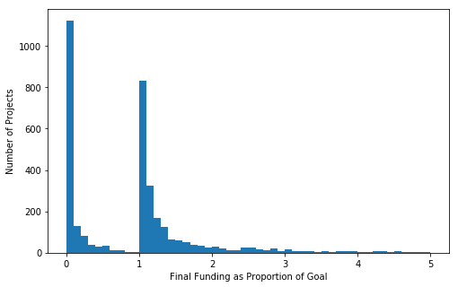

```python
binsize = 0.1
bins = np.arange(0, 5+binsize, binsize)

plt.figure(figsize=[8, 5])
plt.hist(data = df_notlive, x = 'funded_prop', bins = bins)
plt.xlabel('Final Funding as Proportion of Goal')
plt.ylabel('Number of Projects')
plt.show()
```

The distribution of proportion of funding goal met is exponential and bimodal - at 0 (or nearly 0, for those campaigns which received nothing or nearly nothing), and at 1 (representing campaigns that met their goal or even surpassed it by a little bit).

#### What does the area between 0 and 1 look like, when log transformed? This will be exclusive of campaigns that had funding proportions of 0 or 1:

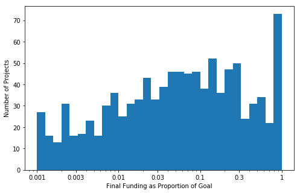

```python
log_binsize = 0.1
bins = 10 ** np.arange(-3, np.log10(0.99)+log_binsize, log_binsize)

plt.figure(figsize=[8, 5])
plt.hist(data = df_notlive, x = 'funded_prop', bins = bins)
plt.xscale('log')
plt.xticks([0.001, 0.003, 0.01, 0.03, 0.1, 0.3, 1], [0.001, 0.003, 0.01, 0.03, 0.1, 0.3, 1])
plt.xlabel('Final Funding as Proportion of Goal')
plt.ylabel('Number of Projects')
plt.show();
```

There appears to be a good quantity of campaigns that didn't meet their goal, but still had some funding.

#### What does the distribution between the median and 75th percentile look like?

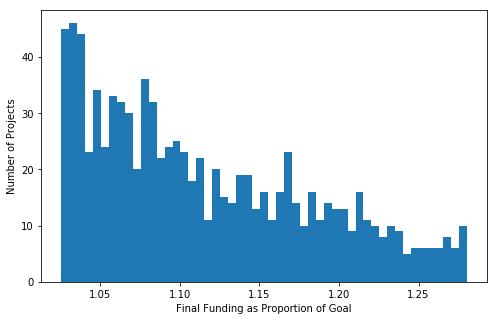

```python
binsize = 0.005
bins = np.arange(df_notlive.funded_prop.median(),
                 df_notlive.funded_prop.quantile(.75)+binsize, binsize)

plt.figure(figsize=[8, 5])
plt.hist(data = df_notlive, x = 'funded_prop', bins = bins)
plt.xlabel('Final Funding as Proportion of Goal')
plt.ylabel('Number of Projects')
plt.show();
```

## Bivariate Exploration

### Exploring Sample-Based Correlations of Continuous Quantitative Variables:

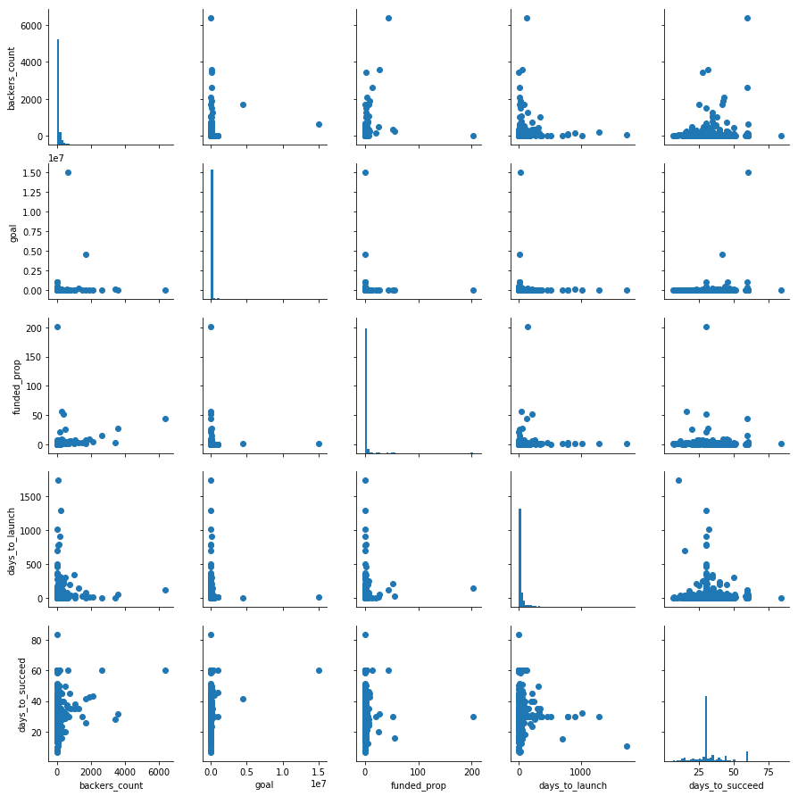

```python
# plot matrix: sample 500 projects so that plots are clearer and render faster
samples = np.random.choice(df_notlive.shape[0], 500, replace = False)
df_samp = df_notlive.reindex(samples)

g = sb.PairGrid(data = df_samp, vars = ['backers_count',
                                        'goal',
                                        'funded_prop',
                                        'days_to_launch',
                                        'days_to_succeed',])
g = g.map_diag(plt.hist, bins = 50);
g.map_offdiag(plt.scatter);
```

Nothing too apparent stands out. Most distributions are just reflective of the independent variable's distribution (i.e. backers_count vs days_to_launch resembles the distribution of days_to_launch).

### Check distribution of success of projects split by 'main_cat'

```python
df_notlive['successful'] = np.where(df_notlive.state == 'successful', True, False)
```

```python
df_notlive[['name','state','successful']].head()
```

|  | name | state | successful |
| --- | --- | --- | --- |
| 0 | OMNI - Intelligent Construction Robots (Canceled) | canceled | False |
| 1 | Diamond's 2015 Cosplay Calendar | failed | False |
| 2 | The Lady In RED | failed | False |
| 3 | MEMORIA PERDIDA: Spain's Lost Memory 1936-1975 | successful | True |
| 4 | THE ROOT OF PERFECTION | successful | True |

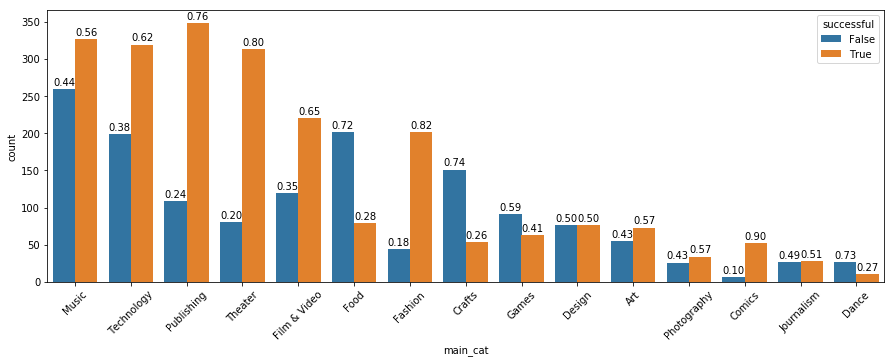

```python
plt.figure(figsize=[15, 5])
ax = sb.countplot(data = df_notlive, x = 'main_cat', hue = 'successful',
                  order= df_notlive['main_cat'].value_counts().index);
loc, labels = plt.xticks()
ax.set_xticklabels(labels, rotation=45);

n_points = df_notlive['main_cat'].value_counts()
i=0
for p in ax.patches:
    if i >= 15:
        i = 0
        height = p.get_height()
        ax.text(p.get_x()+p.get_width()/2., height + 5, '{:.2f}'.format(height/n_points[i]),
                ha = 'center')
        i += 1
    else:
        height = p.get_height()
        ax.text(p.get_x()+p.get_width()/2., height + 5, '{:.2f}'.format(height/n_points[i]),
                ha = 'center')
        i +=1
plt.show;
```

Looks like some categories are very common and successful for Kickstarter campaigns: Music, Technology, Publishing, and Theater. However, even some less common categories have relatively similar success rates, if not better: Comics, Fashion, Film & Video, Art, Photography. A few that are less successful are Food, Crafts, Dance, Games, Design, Journalism.

### Check distribution of success of projects among those with the fewest backers:

```
posx and posy should be finite values
posx and posy should be finite values
```

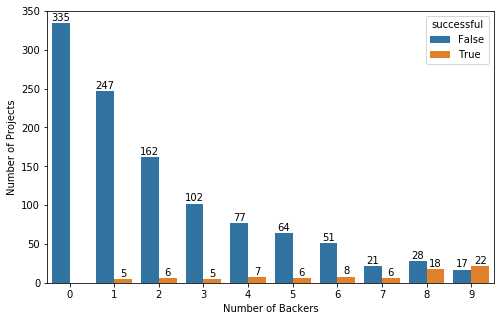

```python
# Plot countplot that illustrates how many projects have fewer than 10 backers,
# split by whether or not they were successful:

plt.figure(figsize=[8, 5])
ax = sb.countplot(data = df_notlive, x = 'backers_count',
                  hue = 'successful')
plt.xlabel('Number of Backers')
plt.ylabel('Number of Projects')
plt.xlim(-0.5,9.5)
plt.ylim(0,350)

# add annotations

for p in ax.patches[0:10]:
    height = p.get_height()
    ax.text(p.get_x()+p.get_width()/2.,
            height + 3,
            '{:.0f}'.format(height),
            ha = 'center')

mid_patch = int(len(ax.patches)/2)
mid_patch10 = int(len(ax.patches)/2+10)
for p in ax.patches[mid_patch:mid_patch10]:
    height = p.get_height()
    ax.text(p.get_x()+p.get_width()/2.,
            height + 3,
            '{:.0f}'.format(height),
            ha = 'center')

plt.show();
```

Looks like starting at 9 contributors, campaigns may have more than a 50% chance of succeeding.

### Check distribution of state of projects relative to them being a Staff Pick:

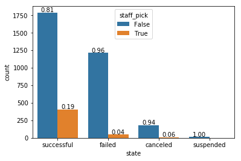

```python
ax = sb.countplot(data = df_notlive, x = 'state', hue = 'staff_pick',
                  order = df_notlive['state'].value_counts().index)

# add annotations
n_points = df_notlive['state'].value_counts()
i=0
for p in ax.patches[0:7]:
    if i >= 4:
        i = 0
        height = p.get_height()
        ax.text(p.get_x()+p.get_width()/2.,
                height + 5,
                '{:.2f}'.format(height/n_points[i]),
                ha = 'center')
        i += 1
    else:
        height = p.get_height()
        ax.text(p.get_x()+p.get_width()/2.,
                height + 5,
                '{:.2f}'.format(height/n_points[i]),
                ha = 'center')
        i +=1

plt.show();
```

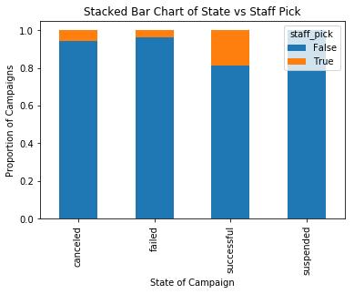

```python
# Reference: https://towardsdatascience.com/building-a-logistic-regression-in-python-step-by-step-becd4d56c9c8
table=pd.crosstab(df_notlive.state,df_notlive.staff_pick)
table.div(table.sum(1).astype(float), axis=0).plot(kind='bar', stacked=True)
plt.title('Stacked Bar Chart of State vs Staff Pick')
plt.xlabel('State of Campaign')
plt.ylabel('Proportion of Campaigns');
```

Almost a fifth of successful campaigns were Staff Picks. However, being a Staff Pick does not guarantee success, as can be seen by the 4% of failed campaigns and 6% of canceled campaigns being Staff Picks.

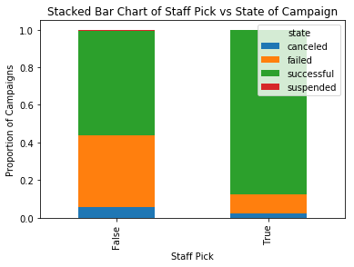

```python
# Reference: https://towardsdatascience.com/building-a-logistic-regression-in-python-step-by-step-becd4d56c9c8
table=pd.crosstab(df_notlive.staff_pick,df_notlive.state)
table.div(table.sum(1).astype(float), axis=0).plot(kind='bar', stacked=True)
plt.title('Stacked Bar Chart of Staff Pick vs State of Campaign')
plt.xlabel('Staff Pick')
plt.ylabel('Proportion of Campaigns');
```

Based on this last bar chart, it appears that campaigns that were selected as Staff Pick were more likely to succeed.

### Compare differences in mean values for various variables among Main Project Categories:

```python
var = ['successful','funded_prop','backers_count','staff_pick','main_cat']
df_notlive[var].groupby('main_cat').mean().sort_values('funded_prop')
```

| main_cat | successful | funded_prop | backers_count | staff_pick |
| --- | --- | --- | --- | --- |
| Dance | 0.270270 | 0.415694 | 42.621622 | 0.216216 |
| Food | 0.281139 | 0.473424 | 54.519573 | 0.106762 |
| Crafts | 0.263415 | 0.717455 | 32.190244 | 0.058537 |
| Journalism | 0.509091 | 0.773997 | 45.000000 | 0.145455 |
| Film & Video | 0.647059 | 0.858393 | 80.041176 | 0.129412 |
| Photography | 0.566667 | 0.883762 | 59.116667 | 0.133333 |
| Theater | 0.796438 | 1.015368 | 73.725191 | 0.127226 |
| Music | 0.557265 | 1.275527 | 56.523077 | 0.087179 |
| Publishing | 0.761488 | 1.328488 | 100.964989 | 0.170678 |
| Games | 0.409091 | 1.716991 | 212.863636 | 0.045455 |
| Comics | 0.896552 | 2.758357 | 132.241379 | 0.293103 |
| Fashion | 0.820408 | 2.923342 | 175.742857 | 0.085714 |
| Design | 0.496732 | 3.361129 | 552.052288 | 0.143791 |
| Technology | 0.615830 | 3.759126 | 409.694981 | 0.181467 |
| Art | 0.570312 | 217.335729 | 51.890625 | 0.117188 |

### Check distribution of Main Project Categories relative to their proportion of being funded:

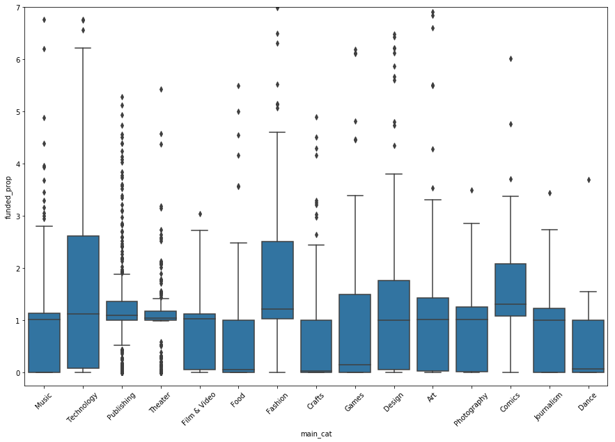

```python
plt.figure(figsize=[15, 10])
ax = sb.boxplot(x='main_cat', y='funded_prop', data=df_notlive, color=base_color, order = df_notlive['main_cat'].value_counts().index)
loc, labels = plt.xticks()
ax.set_xticklabels(labels, rotation=45);
plt.ylim(-0.25,7);
```

Looking at the median point for the boxplots relative to the "1" point on the y-axis, we can see the proportion of projects within each Main Category which met their goal or didn't. Since meeting one's funding goal (getting at least "1" for the funding proportion) defines a Kickstarter campaign success, we can see whether a majority of campaigns succeeded or failed.

### Compare differences in median values for various variables among Main Project Categories:

```python
df_notlive['avg_donation'] = df_notlive['usd_pledged'] / df_notlive['backers_count']
df_notlive['avg_donation'] = df_notlive['avg_donation'].fillna(0)

var = ['successful','funded_prop','avg_donation','backers_count','staff_pick','main_cat']
df_notlive[var].groupby('main_cat').median().sort_values('avg_donation')
```

| main_cat | successful | funded_prop | avg_donation | backers_count | staff_pick |
| --- | --- | --- | --- | --- | --- |
| Crafts | False | 0.034000 | 16.409322 | 2.0 | False |
| Journalism | True | 1.006750 | 26.384189 | 10.0 | False |
| Comics | True | 1.303489 | 31.604394 | 68.5 | False |
| Dance | False | 0.067143 | 33.740000 | 5.0 | False |
| Games | False | 0.148290 | 35.884012 | 23.0 | False |
| Fashion | True | 1.212333 | 39.294118 | 57.0 | False |
| Art | True | 1.014900 | 39.637963 | 19.5 | False |
| Food | False | 0.049219 | 40.057795 | 6.0 | False |
| Music | True | 1.009321 | 40.869028 | 21.0 | False |
| Publishing | True | 1.089600 | 43.971429 | 42.0 | False |
| Photography | True | 1.016813 | 45.306897 | 19.0 | False |
| Design | False | 1.000000 | 57.970588 | 43.0 | False |
| Theater | True | 1.039400 | 64.499612 | 33.0 | False |
| Film & Video | True | 1.026131 | 67.116378 | 39.0 | False |
| Technology | True | 1.121671 | 87.803377 | 77.0 | False |

Here we confirmed that Crafts, Food, Dance, Games, and even Design are categories that have difficulty getting more than half of their projects funded. For Crafts, Food, and Dance, it appears that a low backer count is a contributing factor.

We can explore even further within a Main Category - to see the boxplot distributions of their Subcategories. For instance, let's take Technology:

### Check distribution of Technology Project Subcategories relative to their proportion of being funded:

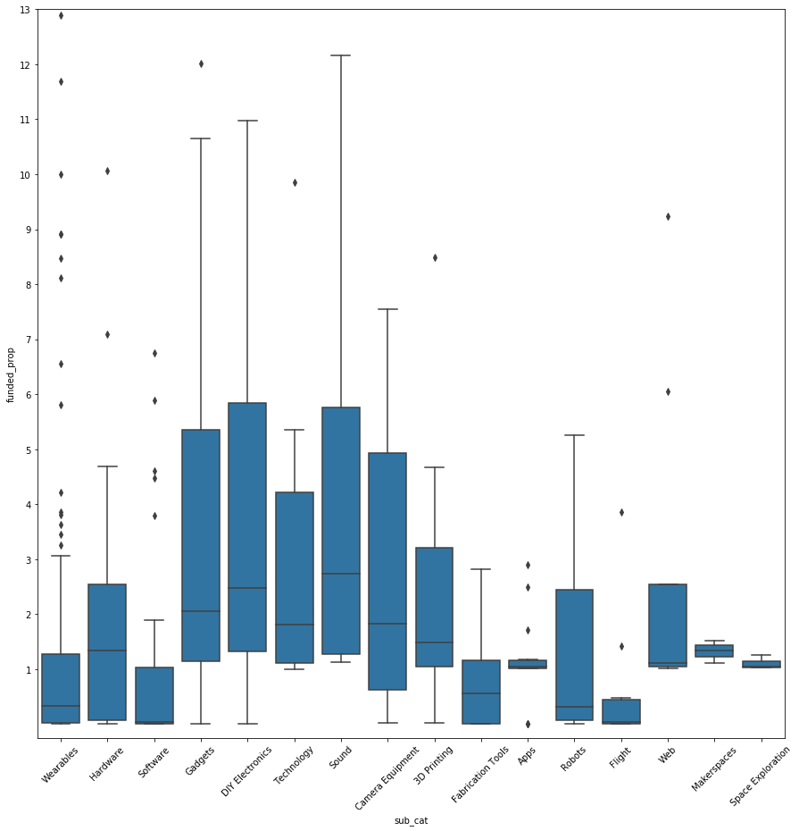

```python
df_sub_tech = df_notlive[df_notlive['main_cat']=='Technology'].copy()

plt.figure(figsize=[15, 15])
ax = sb.boxplot(x='sub_cat', y='funded_prop', data=df_sub_tech, color=base_color, order = df_sub_tech['sub_cat'].value_counts().index)
plt.yticks([1,2,3,4,5,6,7,8,9,10,11,12,13], [1,2,3,4,5,6,7,8,9,10,11,12,13])
loc, labels = plt.xticks()
ax.set_xticklabels(labels, rotation=45);
plt.ylim(-0.25,13);
```

Here we can see that not all technology subcategories are equally successful. Those subcategories which appear to acquire much more funding than requested (and have more than 75% of projects meeting goals) include Gadgets, DIY Electronics, Technology (a bit vague, no?), Sound, and 3D Printing. Apps, Web, Makerspaces, and Space Exploration also have the majority (if not all) of their projects being successful, however not by the same margins. The subcategories which are more likely to not meet their goals are Wearables, Software, Fabrication Tools, and Flight.

```python
var = ['successful','funded_prop','backers_count','staff_pick','sub_cat']
df_sub_tech[var].groupby('sub_cat').mean().sort_values('funded_prop')
```

| sub_cat | successful | funded_prop | backers_count | staff_pick |
| --- | --- | --- | --- | --- |
| Flight | 0.200000 | 0.616862 | 61.400000 | 0.100000 |
| Software | 0.313725 | 0.823171 | 93.627451 | 0.039216 |
| Space Exploration | 1.000000 | 1.108927 | 179.666667 | 0.666667 |
| Apps | 0.785714 | 1.124949 | 227.428571 | 0.071429 |
| Makerspaces | 1.000000 | 1.325637 | 175.333333 | 0.333333 |
| Robots | 0.428571 | 1.393379 | 735.000000 | 0.285714 |
| 3D Printing | 0.800000 | 2.320832 | 131.066667 | 0.133333 |
| Web | 1.000000 | 2.833204 | 345.000000 | 0.111111 |
| Hardware | 0.634921 | 2.893111 | 405.492063 | 0.238095 |
| Fabrication Tools | 0.500000 | 3.184975 | 26.642857 | 0.142857 |
| Gadgets | 0.934783 | 3.853401 | 516.913043 | 0.130435 |
| Wearables | 0.397516 | 4.458556 | 470.335404 | 0.093168 |
| Technology | 1.000000 | 5.008498 | 445.459459 | 0.162162 |
| DIY Electronics | 0.825000 | 5.733002 | 308.475000 | 0.425000 |
| Sound | 1.000000 | 6.300303 | 973.500000 | 0.650000 |
| Camera Equipment | 0.722222 | 7.423610 | 750.611111 | 0.333333 |

## Multivariate Exploration

### Explore spread of projects by their Final State, relative to Proportion of Goal Funded and Number of Backers:

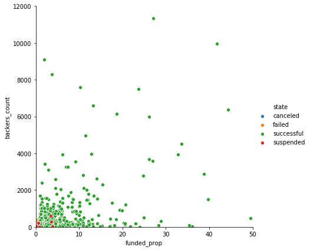

```python
sb.pairplot(x_vars=['funded_prop'], y_vars=['backers_count'], data=df_notlive, hue = 'state', height = 6);
plt.xlim([0,50]);
plt.ylim([0,12000]);
```

#### Let's zoom in:

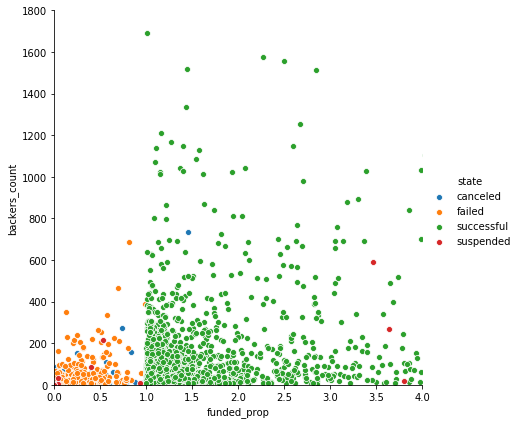

```python
sb.pairplot(x_vars=['funded_prop'], y_vars=['backers_count'], data=df_notlive, hue = 'state', height = 6);
plt.xlim([0,4]);
plt.ylim([0,1800]);
```

This displays what is fairly expected: campaigns that met or exceeded their goal (proportion funded >= 1) are successful. Those that were not able to do so are not.

### Explore spread of Technology projects by their Success, relative to Average Donation and Number of Backers:

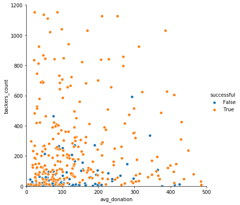

```python
g = sb.pairplot(x_vars=['avg_donation'], y_vars=['backers_count'],
                data=df_notlive[df_notlive['main_cat']=='Technology'],
                hue = 'successful', height = 6);
plt.xlim([0,500]);
plt.ylim([0,1200]);
plt.show();
```

### Explore spread of Game projects by their Success, relative to Average Donation and Number of Backers:

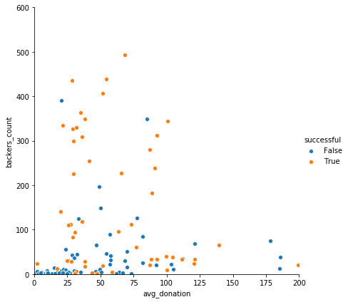

```python
g = sb.pairplot(x_vars=['avg_donation'], y_vars=['backers_count'],
                data=df_notlive[df_notlive['main_cat']=='Games'],
                hue = 'successful', height = 6);
plt.xlim([0,200]);
plt.ylim([0,600]);
plt.show();
```

## Conduct Logistic Regression:

#### Assessing affect on success by Staff Pick, number of backers, and average donations.

```python
df_notlive[['successful_f','successful_t']] = pd.get_dummies(df_notlive['successful'])
df_notlive[['staff_pick_f','staff_pick_t']] = pd.get_dummies(df_notlive['staff_pick'])

import statsmodels.api as sm
df_notlive['intercept'] = 1
logit_mod = sm.Logit(df_notlive['successful_t'], df_notlive[['intercept', 'backers_count', 'avg_donation','staff_pick_t']])
results = logit_mod.fit()
results.summary()
```

```
Optimization terminated successfully.
         Current function value: 79.701771
         Iterations 10
```

Logit Regression Results

| Dep. Variable: | successful_t | No. Observations: | 3669 |
| --- | --- | --- | --- |
| Model: | Logit | Df Residuals: | 3665 |
| Method: | MLE | Df Model: | 3 |
| Date: | Tue, 02 Jul 2019 | Pseudo R-squ.: | inf |
| Time: | 03:39:30 | Log-Likelihood: | -2.9243e+05 |
| converged: | True | LL-Null: | 0.0000 |
|  |  | LLR p-value: | 1.000 |

|  | coef | std err | z | P>\|z\| | [0.025 | 0.975] |
| --- | --- | --- | --- | --- | --- | --- |
| intercept | -1.1020 | 0.060 | -18.293 | 0.000 | -1.220 | -0.984 |
| backers_count | 0.0360 | 0.002 | 21.540 | 0.000 | 0.033 | 0.039 |
| avg_donation | 0.0021 | 0.000 | 5.143 | 0.000 | 0.001 | 0.003 |
| staff_pick_t | -0.1663 | 0.184 | -0.903 | 0.367 | -0.527 | 0.195 |

```python
np.exp(0.0360)
```

```
1.0366558464909237
```

```python
np.exp(0.0021)
```

```
1.0021022065443106
```

For each one additional backer, success is 1.037 times as likely holding all else constant.

For each additional dollar in an average donation, success is 1.0021 times as likely holding all else constant.

Staff Pick is not a statistically significant predictor of project success

```python
df_notlive.to_csv('final_dataset.csv')
```